# Aviso Semanal Focus — Boletim

REC3302 — Introdução a R (FEA-RP/USP)

## 1. Destaques da semana

Na comparação entre as divulgações de 06/11/2026 e 13/11/2026, o Relatório Focus registrou o seguinte comportamento nas medianas das expectativas de mercado: IPCA (caiu), Selic (estável), PIB Total (estável) e Câmbio (subiu).

- IPCA (ref. 2026): entre 06/11/2026 e 13/11/2026, a mediana das expectativas apresentou queda, passando de 5,2195% para 5,1082% (-0,1113 p.p.). O número de respondentes permaneceu em 146.
- Selic (reunião R8/2026): entre 06/11/2026 e 13/11/2026, a mediana das expectativas manteve-se estável, passando de 13,75% para 13,75% (0,00 p.p.). O número de respondentes permaneceu em 144.
- PIB Total (ref. 2026): entre 06/11/2026 e 13/11/2026, a mediana das expectativas manteve-se estável, passando de 1,7546% para 1,7215% (-0,0331 p.p.). O número de respondentes passou de 118 para 119.
- Câmbio (ref. 2026): entre 06/11/2026 e 13/11/2026, a mediana das expectativas apresentou alta, passando de R$ 5,3500 para R$ 5,4000 (+0,0500 R$). O número de respondentes passou de 122 para 121.

## 2. Tabela comparativa

Aviso Semanal Focus

Última divulgação versus divulgação anterior

| Indicador | Referência | Unidade | Data anterior | Data atual | Mediana anterior | Mediana atual | Variação | Tendência |
| --- | --- | --- | --- | --- | --- | --- | --- | --- |
| IPCA | 2026 | % | 6 Nov 2026 | 13 Nov 2026 | 5,2195 | 5,1082 | −0,1113 | caiu |
| Selic | R8/2026 | % | 6 Nov 2026 | 13 Nov 2026 | 13,7500 | 13,7500 | 0,0000 | estável |
| PIB Total | 2026 | % | 6 Nov 2026 | 13 Nov 2026 | 1,7546 | 1,7215 | −0,0331 | estável |
| Câmbio | 2026 | R$/US$ | 6 Nov 2026 | 13 Nov 2026 | 5,3500 | 5,4000 | 0,0500 | subiu |

## 3. Evolução semanal das expectativas

**IPCA**

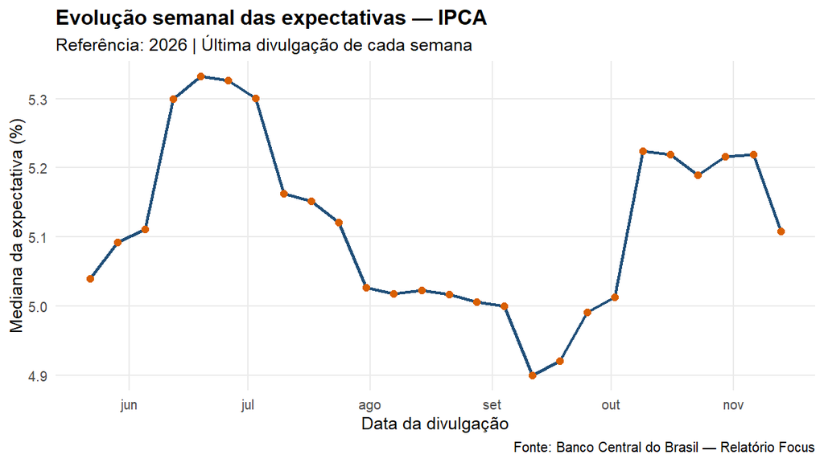

**Selic**

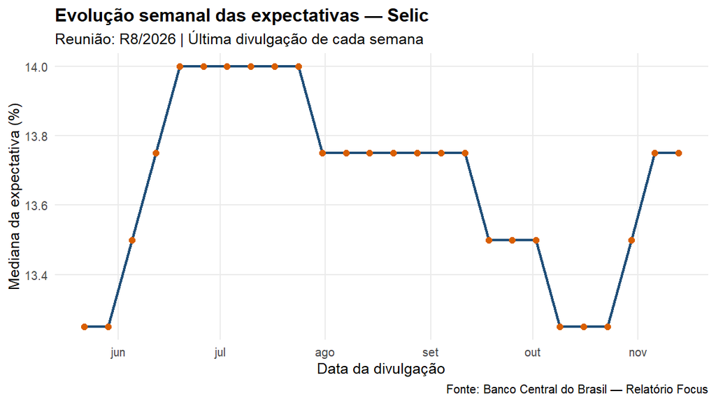

**PIB Total**

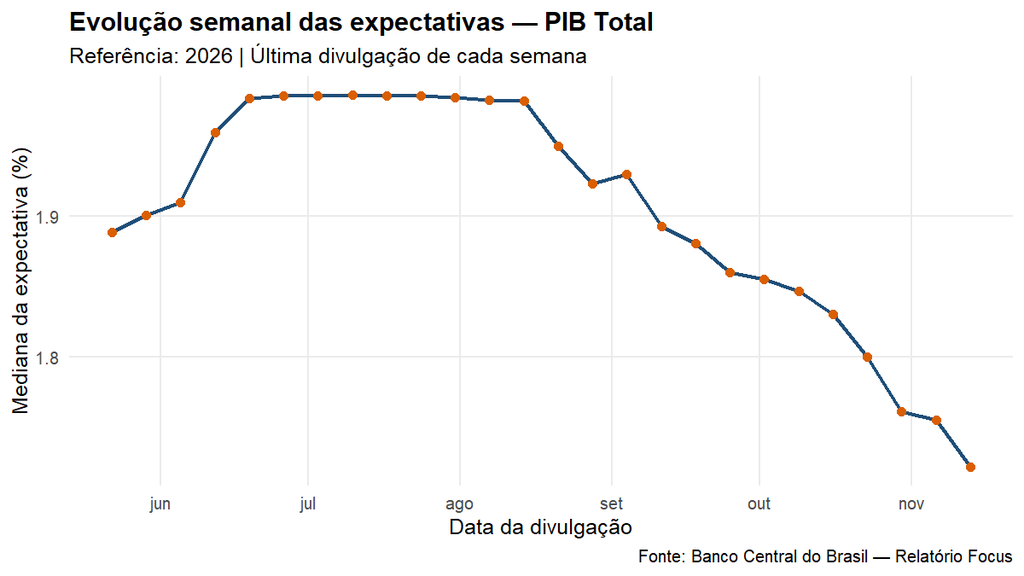

**Câmbio**

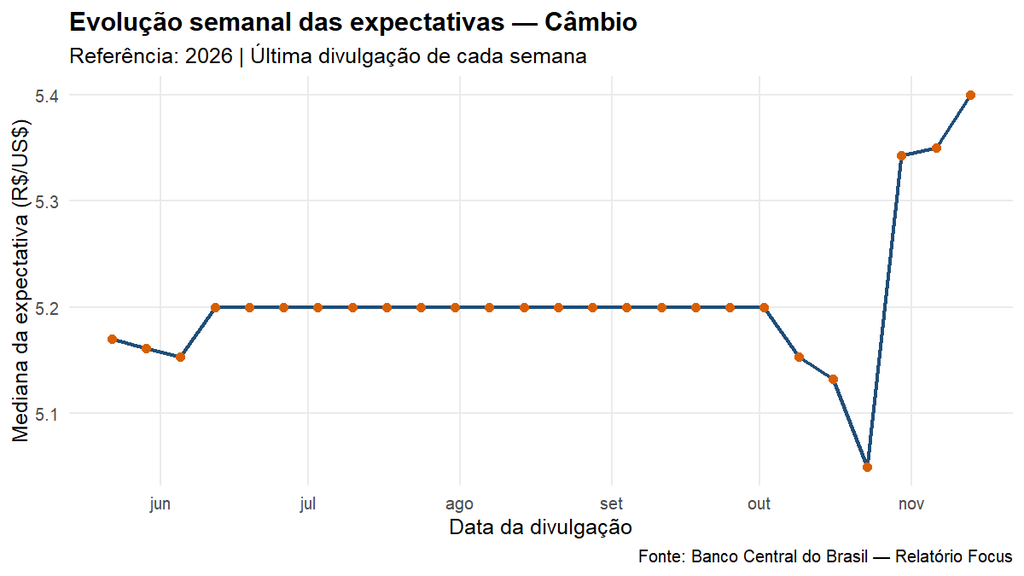

## 4. Metodologia

- Para cada indicador, o boletim compara a **última divulgação de cada uma das duas semanas mais recentes**, desde que sejam consecutivas.
- **Variação = mediana atual − mediana anterior.**
- A tendência é **subiu** se a variação for maior que o limite de estabilidade, **caiu** se for menor que o limite negativo, e **estável** caso contrário.
- Todas as análises usam `baseCalculo == 0`.
- Fonte: Banco Central do Brasil, Sistema Expectativas de Mercado (Relatório Focus).

| Indicador | Referência | Limite de estabilidade |
| --- | --- | --- |
| IPCA | 2026 | 0,05 % |
| Selic | R8/2026 | 0,05 % |
| PIB Total | 2026 | 0,05 % |
| Câmbio | 2026 | 0,02 R$/US$ |